# Visualizing your data with `ggplot`

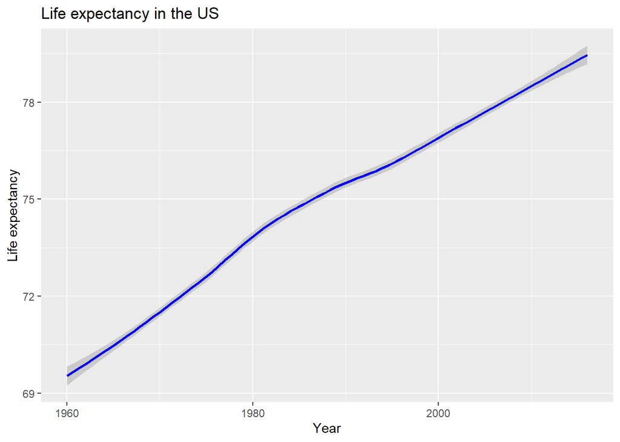

```r
gapminder %>%
  filter(country == "United States") %>%
  ggplot() + # switch to layering with the plus sign once you call the ggplot() function
  geom_smooth(mapping = aes(x = year, y = life_expectancy), color = "blue") +
  labs(x = "Year",
       y = "Life expectancy",
       title = "Life expectancy in the US")
```

If we wanted to make a similar plot for another country, we’d only need to change that small part of the code. Let’s make a life expectancy plot for Sierra Leone using this approach:

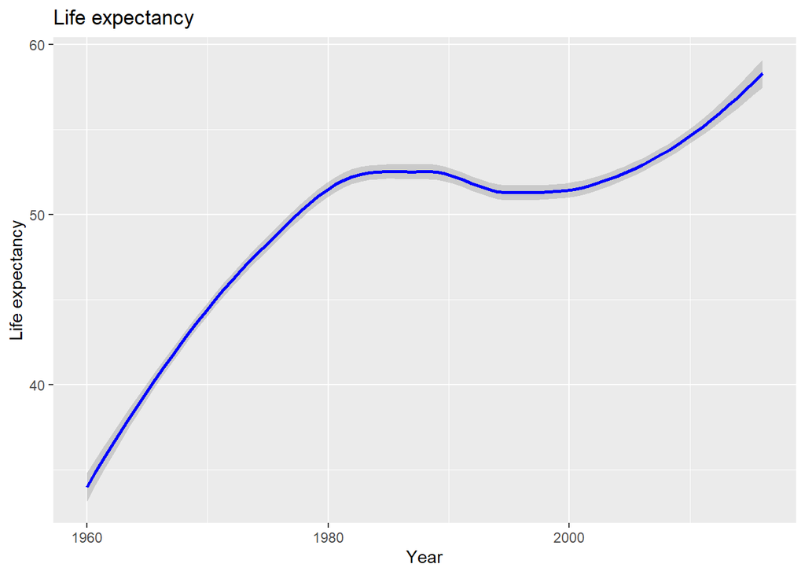

```r
gapminder %>%
  filter(country == "Sierra Leone") %>% # <-- just change country name!
  ggplot() +
  geom_smooth(mapping = aes(x = year, y = life_expectancy), color = "blue") +
  labs(x = "Year",
       y = "Life expectancy",
       title = "Life expectancy")
```

What if we wanted to compare life expectancy in the United States with life expectancy in Sierra Leone in a single plot?

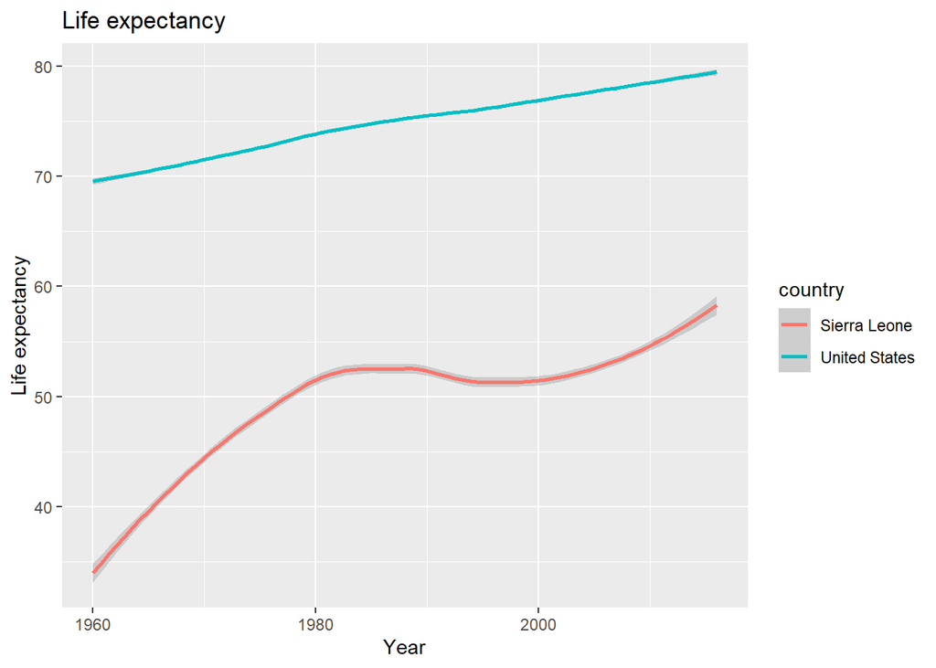

```r
gapminder %>%
  filter(country %in% c("Sierra Leone", "United States")) %>%
  ggplot() +
  geom_smooth(mapping = aes(x = year, y = life_expectancy, color = country)) +
  labs(x = "Year",
       y = "Life expectancy",
       title = "Life expectancy")
```

What if we wanted to add our original points to this visualization? We could just add back the `geom_point()` geometry we used earlier:

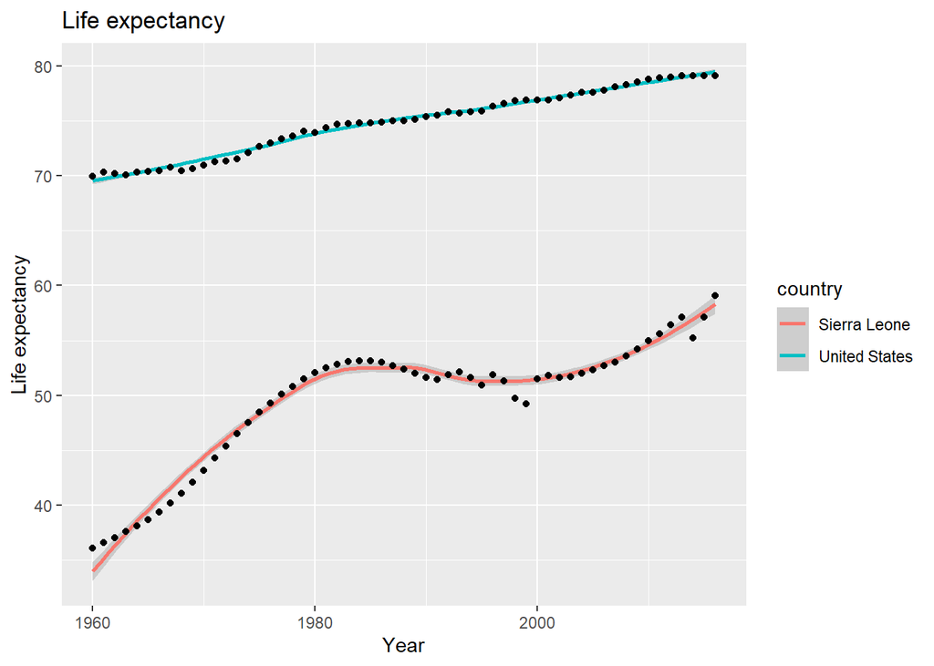

```r
gapminder %>%
  filter(country %in% c("Sierra Leone", "United States")) %>%
  ggplot() +
  geom_smooth(mapping = aes(x = year, y = life_expectancy, color = country)) +
  geom_point(mapping = aes(x = year, y = life_expectancy)) +
  labs(x = "Year",
       y = "Life expectancy",
       title = "Life expectancy")
```

And what if we wanted to do something really cool like, say, change the size of the points to reflect the country’s population in each year?

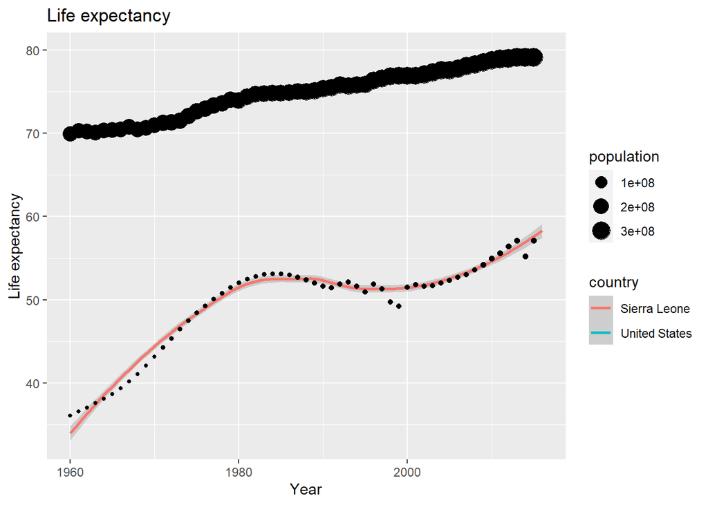

```r
gapminder %>%
  filter(country %in% c("Sierra Leone", "United States")) %>%
  ggplot() +
  geom_smooth(mapping = aes(x = year, y = life_expectancy, color = country)) +
  geom_point(mapping = aes(x = year, y = life_expectancy, size = population)) +
  labs(x = "Year",
       y = "Life expectancy",
       title = "Life expectancy")
```

Every `ggplot` you will ever make (including maps) follows a similar logic. Start by calling the `ggplot()` function. Tell `ggplot()` which dataset you want to visualize. Then slowly add (`+`) the geometries and other information you want to visualize.

## Improving our visualization

Go ahead and say it, that last viz was U-G-L-Y. In what follows, I’m going to show you some of my favorite tricks to improve the quality of visualizations made in `ggplot`. Let’s revisit one of our plots above. I’m going to save this plot in an object (`p`). This means if/as we want to change the plot, we simply have to call the plot and add additional layers! Much easier than re-copying the code a million times!

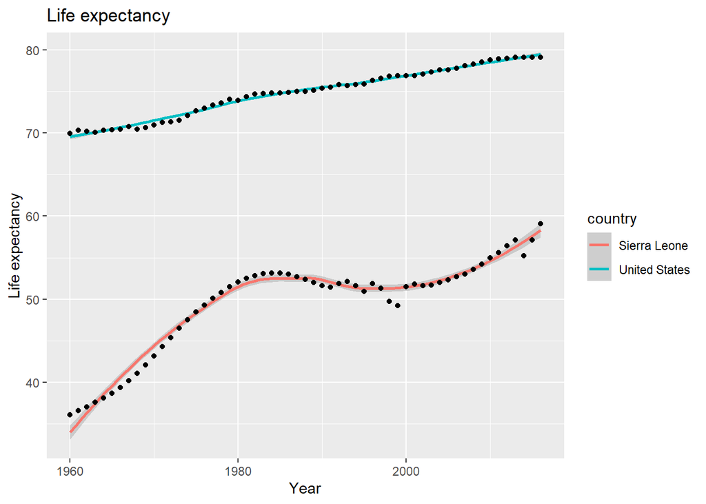

```r
p <- gapminder %>%
  filter(country %in% c("Sierra Leone", "United States")) %>%
  ggplot() +
  geom_smooth(mapping = aes(x = year, y = life_expectancy, color = country)) +
  geom_point(mapping = aes(x = year, y = life_expectancy)) +
  labs(x = "Year",
       y = "Life expectancy",
       title = "Life expectancy")

p
```

Ok, there are a few things that could be improved here:

- The legend is weird.
- We can do better than the default `ggplot` gray square background.
- Let’s change the color of the lines and points.
- Lots more…?

## Themes

One of my favorite things about `ggplot` is the ability to use themes. A theme sets the grid marks, grid color, axis label text and size, and other parameters. The default theme in `ggplot` is OK, but I’m not a fan of the big gray background . Changing your theme is a very easy way to change your plot. Everything you ever wanted to know about themes can be found [here](https://ggplot2.tidyverse.org/reference/ggtheme.html) but let’s play with a few quickly.

`theme_bw()` remove the gray background:

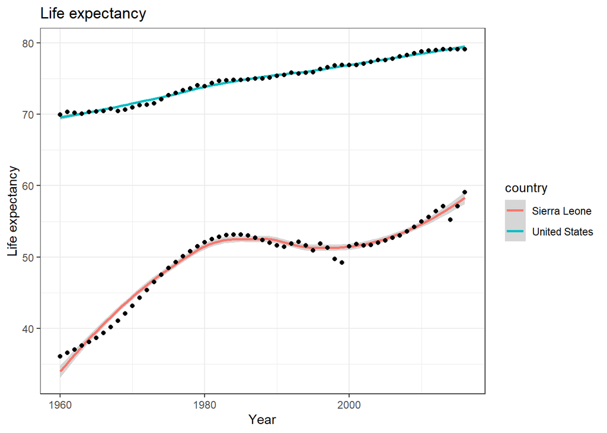

```r
p +
  theme_bw()
```

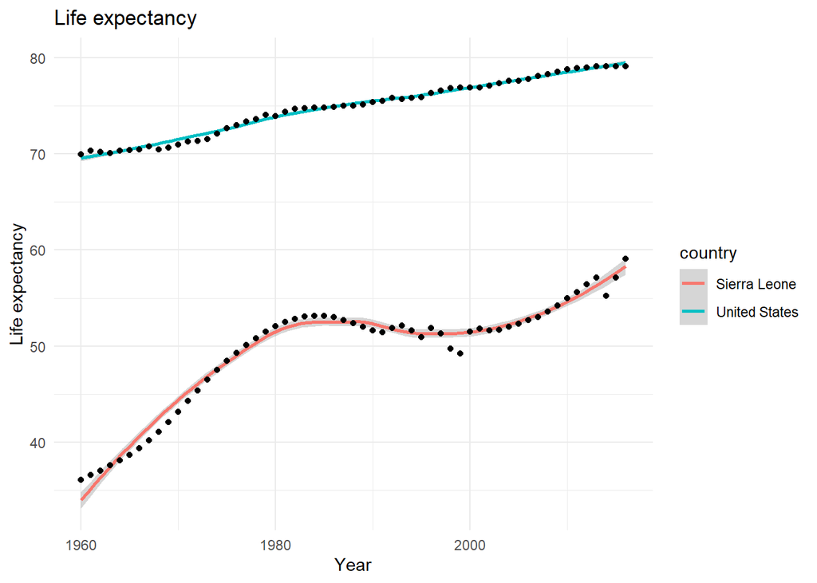

```r
p +
  theme_minimal()
```

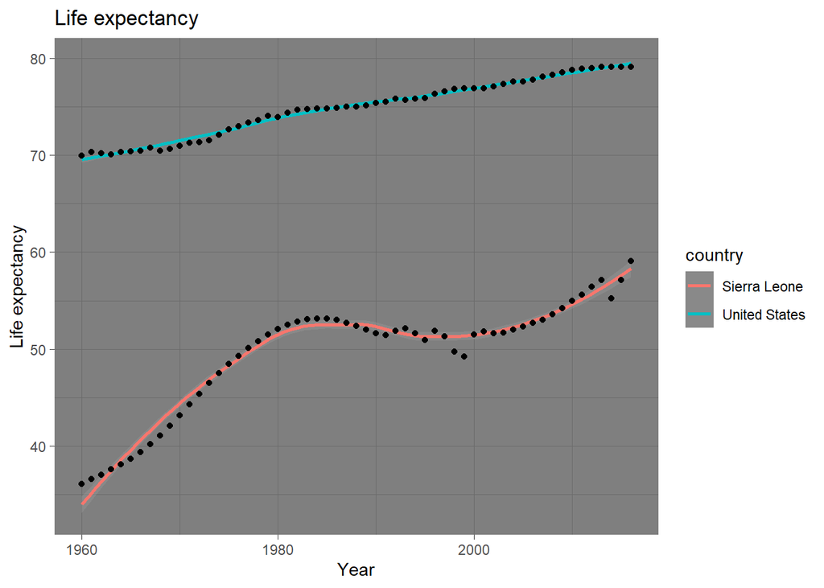

```r
p +
  theme_dark()
```

If you want to go theme-crazy (YES), install the `ggthemes` package:

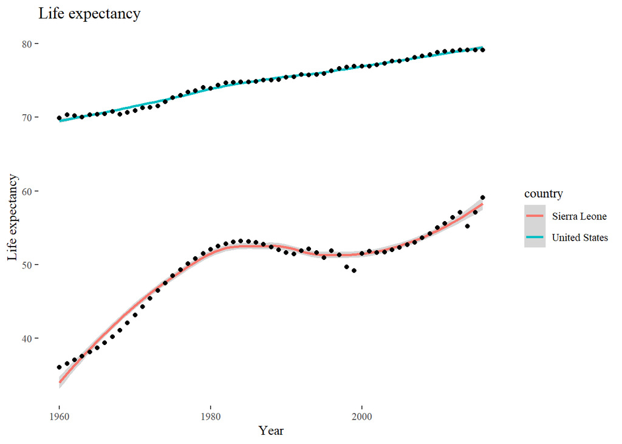

```r
library(ggthemes)
p +
  theme_tufte()
```

I love me some Tufte. To read more about his work, including the creation of the box and whisker plot we’ll learn about next week, [check this out.](https://www.edwardtufte.com/tufte/)

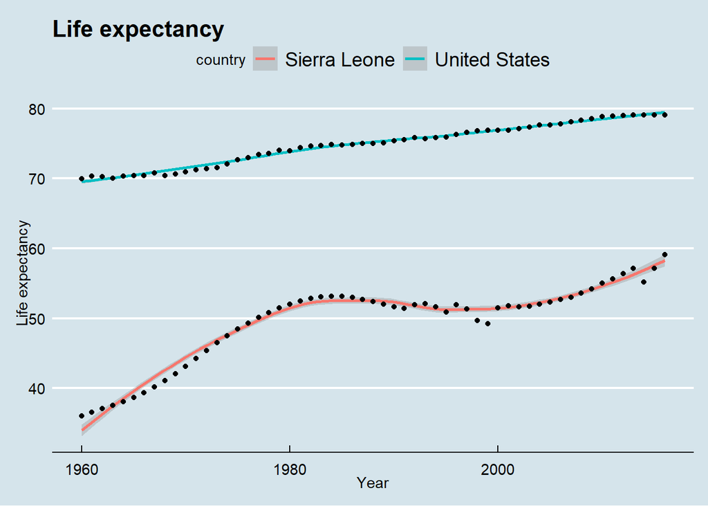

```r
# The Economist
p +
  theme_economist()
```

You can see all ggthemes [here](https://yutannihilation.github.io/allYourFigureAreBelongToUs/ggthemes/). You can also explore the many many ways you can amp up your ggplotting skills (animations anyone?) [here](https://www.ggplot2-exts.org/ggiraph.html).

## Legends

Moving forward, I’ll go with the `theme_bw()`. Let’s now shift to altering our ugly legend. Changing the legend *title* is as easy as:

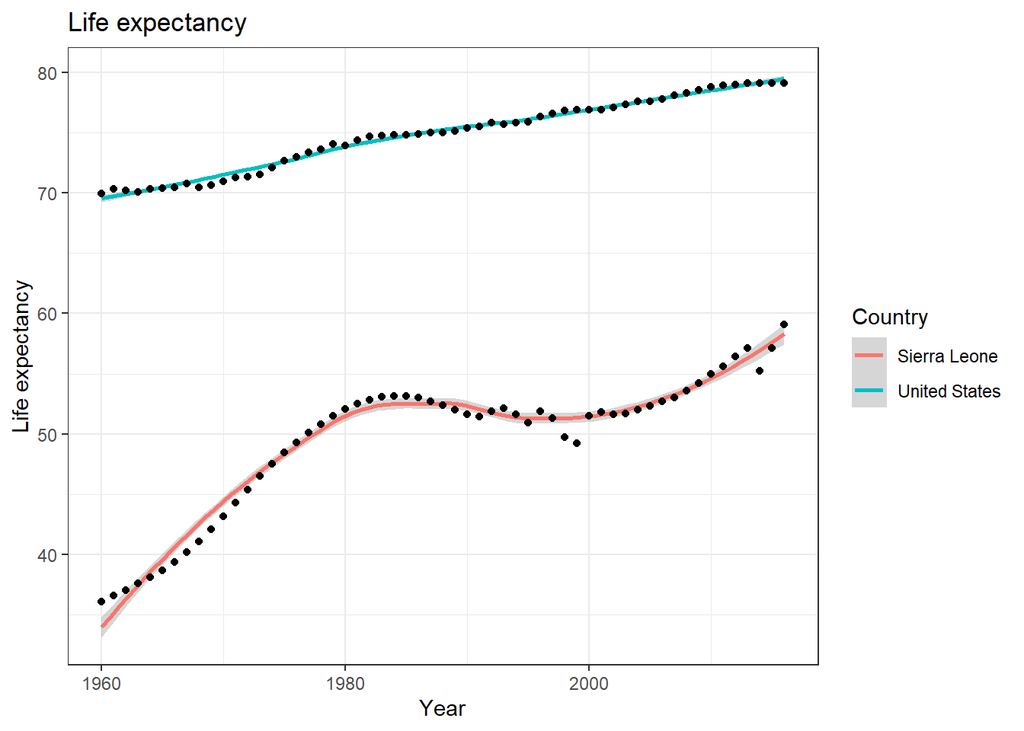

```r
p +
  theme_bw() +
  labs(color = "Country")
```

Note that if your legend refers to something other than color (size, alpha, fill), then you’d just use that aesthetic instead of color (so in the `labs()` fuction, add an argument like `fill = "NAME OF FILL VARIABLE"`). What if we just want to drop the legend title, since it’s fairly clear that we’re talking about countries here:

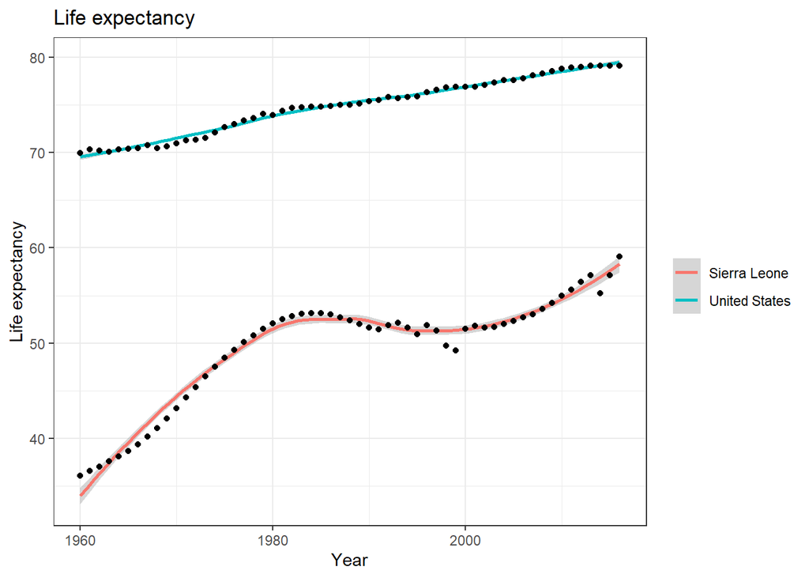

```r
p +
  theme_bw() +
  theme(legend.title = element_blank())
```

Finally, if you’re a little OCD about your visualizations, you can drop the gray background in the legend with the following:

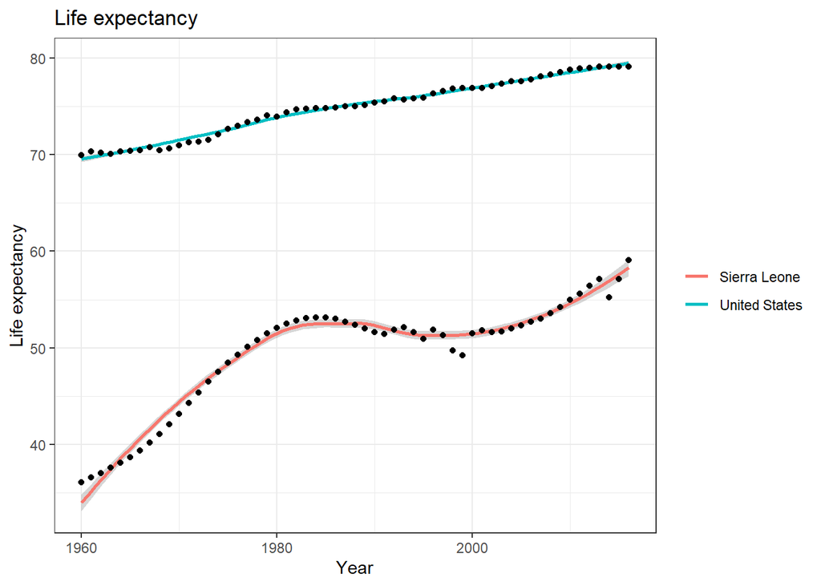

```r
p +
  theme_bw() +
  theme(legend.title = element_blank()) +
  guides(color=guide_legend(override.aes=list(fill=NA)))
```

Nice. Notice that if you look at ALL of the code used to make `p`, it can be very overwhelming. IF, however, you think of this as a layered graphic and approach things (with some help from [StackExchange](https://stackoverflow.com/questions/21066077/remove-fill-around-legend-key-in-ggplot)) one layer at a time, you can easily make fairly complex graphics.

Now what if we want to remove the legend altogether?

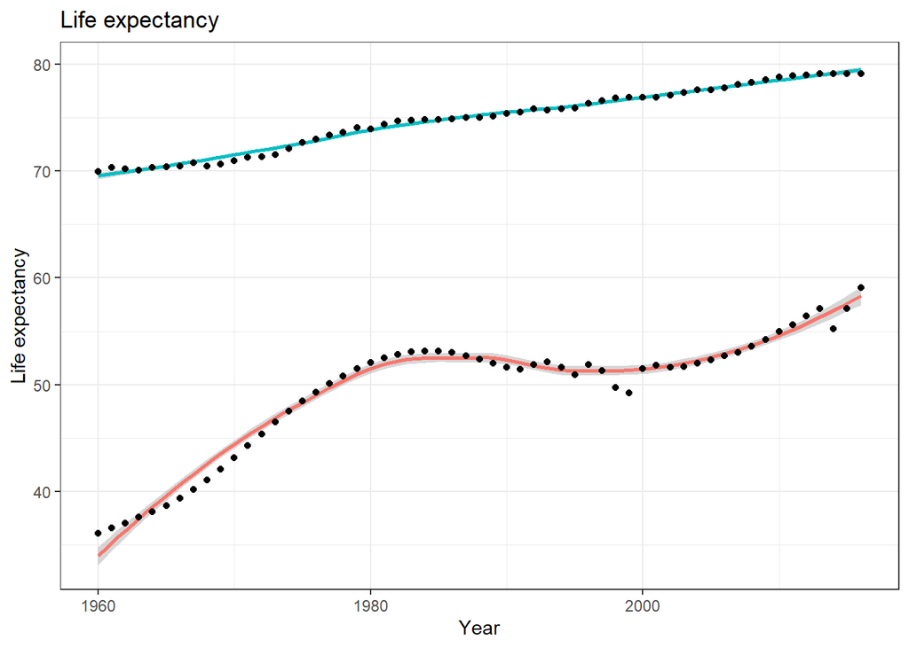

```r
p +
  theme_bw() +
  theme(legend.position="none")
```

You can read everything you ever wanted to know about `ggplot` legends here and also [here](https://www.datanovia.com/en/blog/ggplot-legend-title-position-and-labels/#change-legend-title). This includes more on how to move the legend, change the background of the legend, and alter the elements in the legend.

## Axes

Ok, let’s update our plot with the new legend that drops the “Country” title:

```r
# this replaces the original p object with a new object with our legend edits
p <- p +
  theme_bw() +
  theme(legend.title = element_blank()) +
  guides(color=guide_legend(override.aes=list(fill=NA)))
```

You can change everything about the axis labels, from font type to font size. [This website](http://www.sthda.com/english/wiki/ggplot2-axis-ticks-a-guide-to-customize-tick-marks-and-labels) provides a great overview of altering axes.

The basic formula for changing axis ticks is:

```r
# x axis tick mark labels
p + theme(axis.text.x= element_text(family, face, colour, size))
# y axis tick mark labels
p + theme(axis.text.y = element_text(family, face, colour, size))
```

Where:

- family : font family
- face : font face. Possible values are “plain”, “*italica*”, “**bold**”, and “**bold**.*italica*”
- color : text color
- size : text size in pts
- angle : angle (in [0, 360])

So imagine we want to increase the size of the numbers on the axis and tilt these numbers at 45 degrees. Let’s also make them blue using the hex-code for aqua.

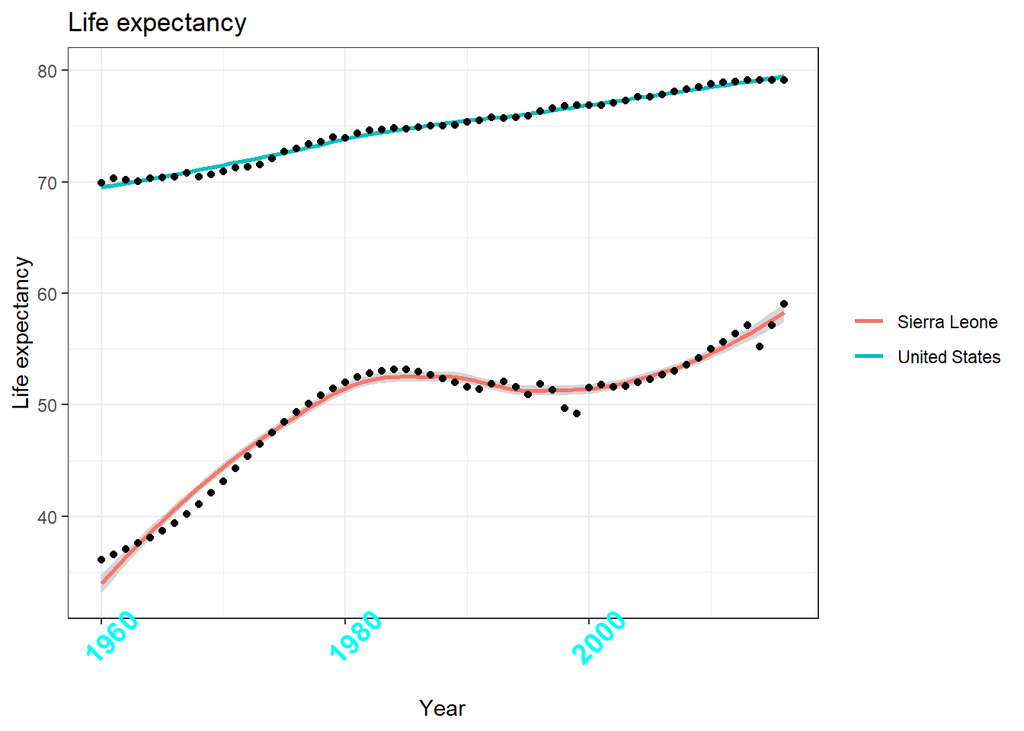

```r
p + theme(axis.text.x= element_text(face = "bold", colour = "#00FFFF", size = 14, angle = 45))
```

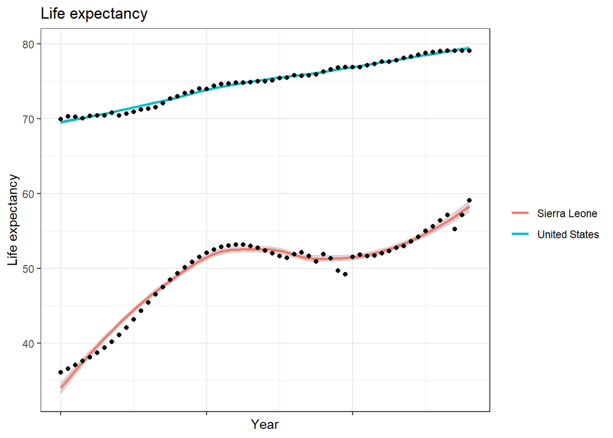

```r
p + theme(axis.text.x= element_blank())
```

If you review the material [on this website](http://www.sthda.com/english/wiki/ggplot2-axis-ticks-a-guide-to-customize-tick-marks-and-labels) you can also learn how to change axis lines, tick resolution, tick mark labels, and the order of items in your plot.

## Title and labels

Here’s [a full overview](http://www.sthda.com/english/wiki/ggplot2-title-main-axis-and-legend-titles#change-the-main-title-and-axis-labels) of how to edit the title and labels in `ggplot`. I’ll overview some of the “best of” below. The basic formula for altering these elements of your plot is:

```r
# main title
p + theme(plot.title = element_text(family, face, colour, size))
# x axis title
p + theme(axis.title.x = element_text(family, face, colour, size))
# y axis title
p + theme(axis.title.y = element_text(family, face, colour, size))
```

Where:

- family : font family
- face : font face. Possible values are “plain”, “italica”, “bold”, and “bold.italica”
- colour : text color
- size : text size in pts
- hjust : horizontal justification (in [0, 1])
- vjust : vertical justification (in [0, 1])
- lineheight : line height. In multi-line text, the lineheight argument is used to change the spacing between lines.
- color : an alias for colour

Here’s an example in which we make the title crazy:

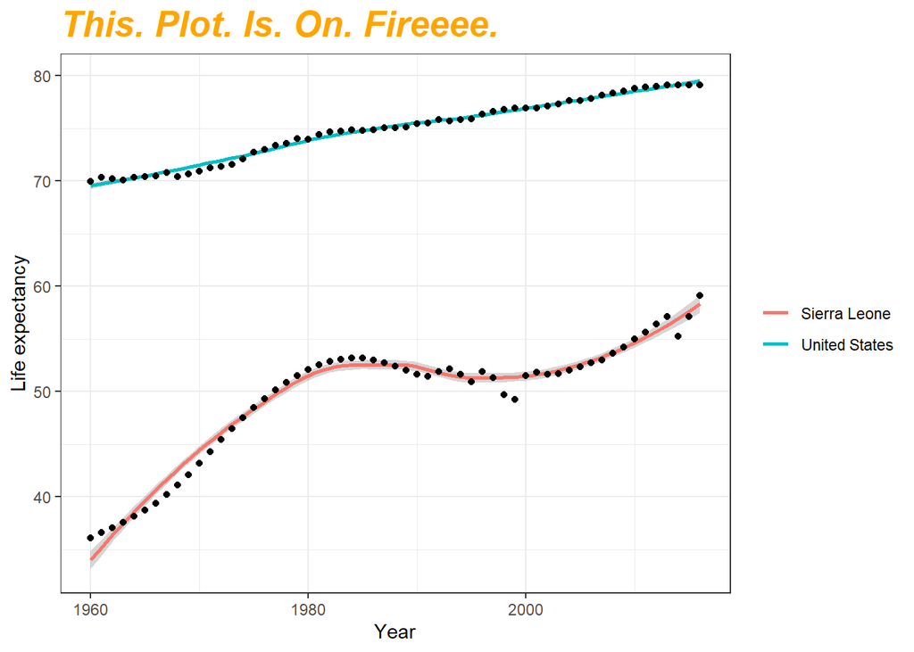

```r
p +
  labs(title = "This. Plot. Is. On. Fireeee.") +
  theme(plot.title = element_text(color = "orange", size = 20, face = "bold.italic"))
```

You can remove axis labels as follows:

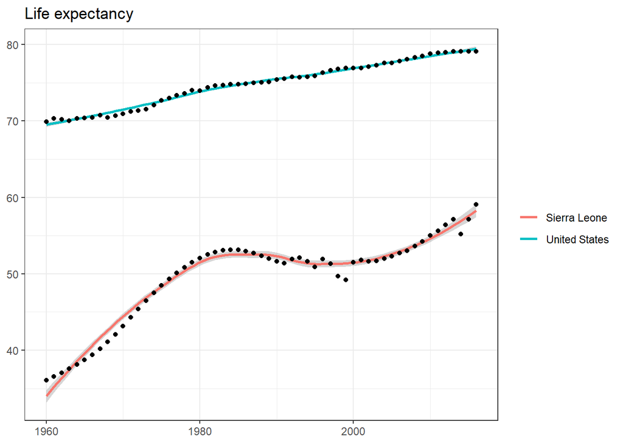

```r
p + theme(axis.title.y = element_blank(),
          axis.title.x = element_blank())
```

Now, to actually edit the *text* content of titles and axis labels, I use the labs function:

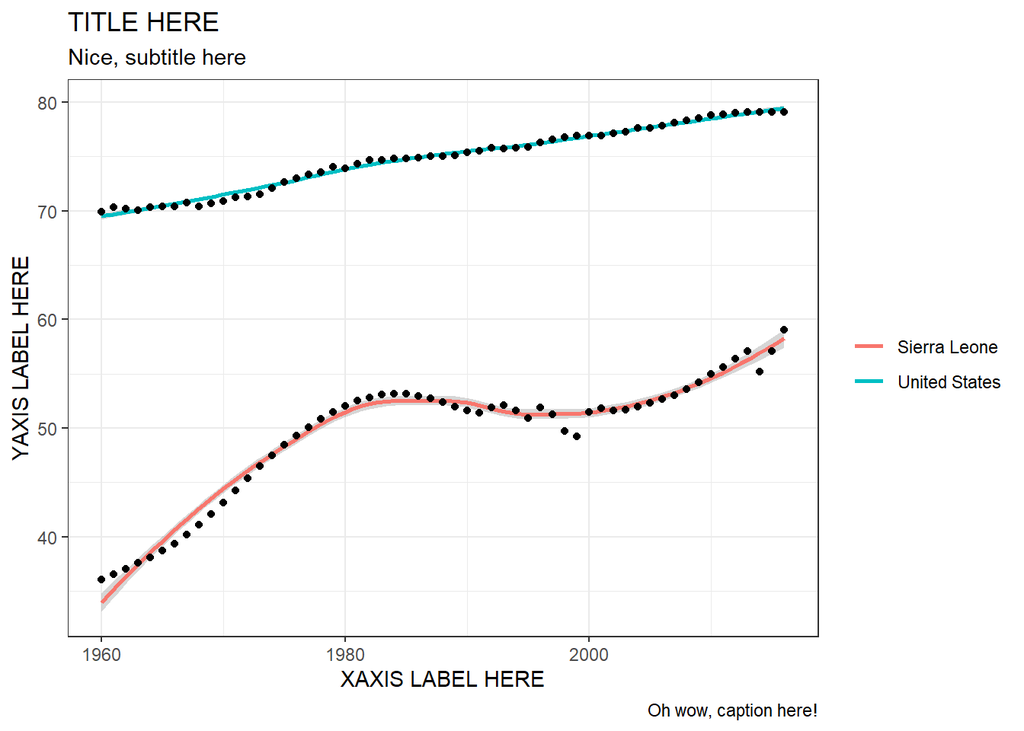

```r
p +
  labs(x = "XAXIS LABEL HERE",
       y = "YAXIS LABEL HERE",
       title = "TITLE HERE",
       subtitle = "Nice, subtitle here",
       caption = "Oh wow, caption here!") # this is also where you can add legend titles for size, color, fill etc...
```